# Angular dispersion

01 October, 2021

## Objective

This example illustrates the calculation of far-field cross-sections for multiple angles of incidence. The structure consists of two silver spheres in water, and all parameters are kept to their default values.

This simulation uses the following `input` file

```
Wavelength 300 700 200

Medium 1.7689 # epsilon of water

Incidence  -7 0.0 0.0 4 1 1 # 7 incidences along phi in [0, pi/2]

OutputFormat HDF5 results

Scatterers 2
Ag -40.0 0.0 0.0 30.0
Ag  40.0 0.0 0.0 30.0
```

The command to run the example is simply

```
../../build/terms input > log
```

The full log contains basic details of the calculations, and finishes with the timing.

**Show log file (click to open)**

```
readInputFile> Parsing file input

readInputFile> Detected keyword Wavelength
               Wavelength LB (nm):   300.000000
               Wavelength UB (nm):   700.000000
               nsteps, step:       200    2.0000
readInputFile> Detected keyword Medium
               Constant host epsilon=  1.7689E+0
readInputFile> Detected keyword Incidence
readInputFile> Euler angle alpha [0,2Pi) grid-points:    7
readInputFile> Modified alpha maximum:   1.57079633
readInputFile> Euler angle beta  [0,Pi]  value=   0.00000000
readInputFile> Euler angle gamma [0,2Pi) value=   0.00000000
               Incident Euler angles and weights:
                  alpha        beta        gamma        weight
               0.11219974   0.00000000   0.00000000   0.14285714
               0.33659921   0.00000000   0.00000000   0.14285714
               0.56099869   0.00000000   0.00000000   0.14285714
               0.78539816   0.00000000   0.00000000   0.14285714
               1.00979764   0.00000000   0.00000000   0.14285714
               1.23419711   0.00000000   0.00000000   0.14285714
               1.45859659   0.00000000   0.00000000   0.14285714
readInputFile> Detected keyword OutputFormat
               OutputFormat=HDF5
               All output files are stored in file "results.h5                                                      "

readInputFile> Detected keyword Scatterers
 with nscat=    2

readInputFile> Descriptor(s) and circumscribing sphere(s):

 scatID String                  x          y          z         R_0
    1   Ag                 -4.0000E+1  0.0000E+0  0.0000E+0  3.0000E+1
    2   Ag                  4.0000E+1  0.0000E+0  0.0000E+0  3.0000E+1

readInputFile> Individual geometry characteristic(s):

 scatID Details
    1   Mie with ncoats= 0
    2   Mie with ncoats= 0

readInputFile> Dielectric functions for (coated) Mie scatterer(s):

 scatID volID Label
    1     0     Ag
    2     0     Ag

readInputFile> Finished parsing  5 keywords


spectrumFF> ===== Wavelength:   300.00 (nm) ======================

           1
           2
           3
           4
           1
           2
           3
           4
           1
           2
...
termsProgram> Program run time (CPU & real in s):  2.165E+01  1.589E+01
```

The output consists of a single hdf5 file, storing the far-field cross-sections for each order from 1 to $n_{1}$ for orientation-averaged quantities (as in example 01), and for each angle of incidence for fixed-orientation quantities, preceded by their average,

**Show file `results.h5`` (click to open)**

```
                           group               name       otype dclass     dim
0                              /          Far-Field   H5I_GROUP
1                     /Far-Field        Wavelengths H5I_DATASET  FLOAT     201
2                     /Far-Field    fixed_incidence   H5I_GROUP
3     /Far-Field/fixed_incidence            Weights H5I_DATASET  FLOAT       7
4     /Far-Field/fixed_incidence            csAbs1X H5I_DATASET  FLOAT 201 x 8
5     /Far-Field/fixed_incidence            csAbs2Y H5I_DATASET  FLOAT 201 x 8
6     /Far-Field/fixed_incidence            csAbs3R H5I_DATASET  FLOAT 201 x 8
7     /Far-Field/fixed_incidence            csAbs4L H5I_DATASET  FLOAT 201 x 8
8     /Far-Field/fixed_incidence            csExt1X H5I_DATASET  FLOAT 201 x 8
9     /Far-Field/fixed_incidence            csExt2Y H5I_DATASET  FLOAT 201 x 8
10    /Far-Field/fixed_incidence            csExt3R H5I_DATASET  FLOAT 201 x 8
11    /Far-Field/fixed_incidence            csExt4L H5I_DATASET  FLOAT 201 x 8
12    /Far-Field/fixed_incidence            csSca1X H5I_DATASET  FLOAT 201 x 8
13    /Far-Field/fixed_incidence            csSca2Y H5I_DATASET  FLOAT 201 x 8
14    /Far-Field/fixed_incidence            csSca3R H5I_DATASET  FLOAT 201 x 8
15    /Far-Field/fixed_incidence            csSca4L H5I_DATASET  FLOAT 201 x 8
16                    /Far-Field       oa_incidence   H5I_GROUP
17       /Far-Field/oa_incidence            cdAbsOA H5I_DATASET  FLOAT 201 x 9
18       /Far-Field/oa_incidence            cdExtOA H5I_DATASET  FLOAT 201 x 9
19       /Far-Field/oa_incidence            cdScaOA H5I_DATASET  FLOAT 201 x 9
20       /Far-Field/oa_incidence            csAbsOA H5I_DATASET  FLOAT 201 x 9
21       /Far-Field/oa_incidence            csExtOA H5I_DATASET  FLOAT 201 x 9
22       /Far-Field/oa_incidence            csScaOA H5I_DATASET  FLOAT 201 x 9
23                    /Far-Field partial_absorption   H5I_GROUP
24 /Far-Field/partial_absorption csAbs1X_scat1coat0 H5I_DATASET  FLOAT 201 x 8
25 /Far-Field/partial_absorption csAbs1X_scat2coat0 H5I_DATASET  FLOAT 201 x 8
26 /Far-Field/partial_absorption csAbs2Y_scat1coat0 H5I_DATASET  FLOAT 201 x 8
27 /Far-Field/partial_absorption csAbs2Y_scat2coat0 H5I_DATASET  FLOAT 201 x 8
28 /Far-Field/partial_absorption csAbs3R_scat1coat0 H5I_DATASET  FLOAT 201 x 8
29 /Far-Field/partial_absorption csAbs3R_scat2coat0 H5I_DATASET  FLOAT 201 x 8
30 /Far-Field/partial_absorption csAbs4L_scat1coat0 H5I_DATASET  FLOAT 201 x 8
31 /Far-Field/partial_absorption csAbs4L_scat2coat0 H5I_DATASET  FLOAT 201 x 8
```

## Fixed-orientation results

The following files contain fixed-orientation cross-sections for X and Y linear polarisations,

```
Rows: 4,824
Columns: 7
$ wavelength    <dbl> 300, 302, 304, 306, 308, 310, 312, 314, 316, 318, 320, 3…
$ crosstype     <chr> "Abs", "Abs", "Abs", "Abs", "Abs", "Abs", "Abs", "Abs", …
$ variable      <fct> total, total, total, total, total, total, total, total, …
$ polarisation1 <dbl> 517.0628, 535.7703, 555.4620, 576.2164, 598.1213, 621.27…
$ polarisation2 <dbl> 517.0628, 535.7703, 555.4620, 576.2164, 598.1213, 621.27…
$ dichroism     <dbl> -4.206413e-12, -2.955858e-12, -3.183231e-12, -4.774847e-…
$ average       <dbl> 517.0628, 535.7703, 555.4620, 576.2164, 598.1213, 621.27…
```

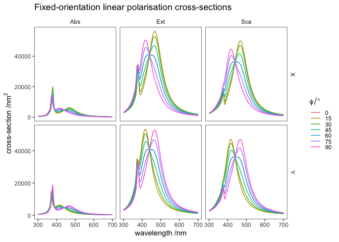

Because we are rotating $\phi$ from 0 to 90 degrees, the two polarisations show the opposite trend as the incident electric field rotates from x to y.

*Last run: 01 October, 2021*